# The Hidden Treasure & the Pearl

by Kameron York

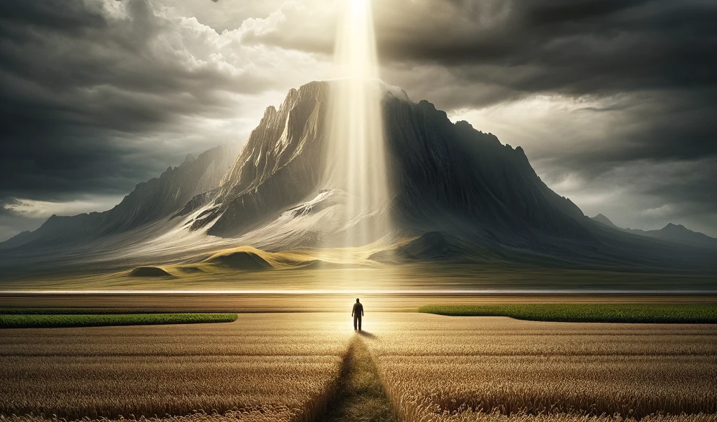

#### Reference:

[Matthew 13:44-46](https://www.churchofjesuschrist.org/study/scriptures/nt/matt/13?lang=eng&id=44-46#p44)

#### What are the Parables of the Hidden Treasure and the Pearl?

These two stories are parables told by Jesus that are only found in the Gospel of Matthew. They share many similarities and a few interesting differences. Both the parable of the hidden treasure and the pearl are about a man that finds a highly valuable object and decides to sell everything he owns to buy it. Interestingly the reason behind finding the valuable object seems different in each parable. While the parable of the Pearl is about a man who is actively seeking, “Goodly pearls,” the man in the parable of the hidden treasure seems to find the treasure by chance.

#### Significance of a Pearl

Pearls are the only gem material that are found and formed in a living creature. They require no cutting or polishing because they are beautiful as they are found. Pearls will lose their shine over time if they are not worn. The oils on skin will naturally keep pearls shiny.

How does this relate the the Gospel of Jesus Christ? The Gospel is beautiful as it is found. The men in the parables sold all that they owned to have the Gospel. Like the pearl losing it’s shine, a disciple can lose faith over time if they aren’t working to live like Christ. Holding a pearl close will help it to keep it’s shine, and holding the Gospel of Jesus Christ close to our hearts will help us to keep faith.

#### What do the Two Kinds of Discovery Mean?

We can learn a lot about individual Gospel discovery through the methods by which these men found treasure. While there are many people who recognize something is missing in their lives and actively seek out the Gospel, some people find the Gospel by chance. Through contacts with missionaries or neighbors these seekers begin their journeys like the man who came across treasure in a field. The important through-line of these parables is the reaction to finding treasure: each man sold all he owned to purchase the treasure (or the field in which the treasure was).

#### Why is Selling Everything they Owned Important?

In order to have enough money to purchase the pearl or the field the man had to sell **all** that he owned. This relationship between the man’s possessions and the treasure seems to be mutually exclusive. There is no price mentioned for the pearl or the field, except that it took every last thing they owned to buy it. So, what does selling everything they owned represent?

While we are not required to sell all of our possessions to follow Christ, we **are** commanded to offer all of our, heart, soul, and mind in love of God. The idea of selling all of our possessions in order to obtain the Gospel of Jesus Christ also implies that nothing is more important than the Gospel. The men in each parable valued the treasure more than their possessions.

#### What do the Symbols in the Parables Represent?

The Man - Us.  
The Treasure - The Gospel of Jesus Christ.  
The Field (The Market) - The Church of Jesus Christ.  
His Possessions - Worldly things / Beliefs.

[output not shown]